# Reproducible Research: Peer Assessment 1

## Loading and preprocessing the data

```r
activity_data <- read.csv(unz("activity.zip", "activity.csv"))
```

## What is mean total number of steps taken per day?

- Make a histogram of the total number of steps taken each day

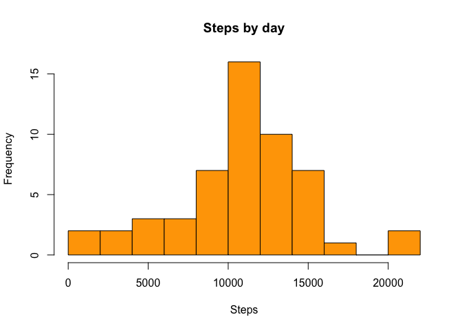

```r
steps_by_date <- aggregate(steps~date,activity_data,sum)
hist(steps_by_date$steps,breaks=10,main="Steps by day", xlab = "Steps", col = "orange")
```

- Calculate and report the **mean** and **median** total number of steps taken per day

```r
mean(steps_by_date$steps)
```

```
## [1] 10766.19
```

```r
median(steps_by_date$steps)
```

```
## [1] 10765
```

## What is the average daily activity pattern?

- Make a time series plot (i.e. type = “l”) of the 5-minute interval (x-axis) and the average number of steps taken, averaged across all days (y-axis)

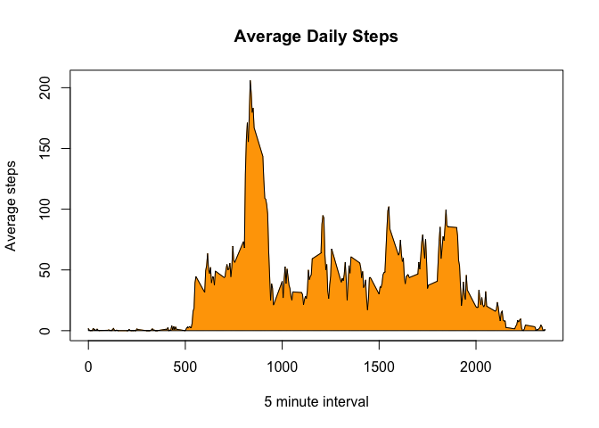

```r
steps_by_interval <- aggregate(steps ~ interval, activity_data, mean)
max_interval <- steps_by_interval$interval[which.max(steps_by_interval$steps)]
plot(steps_by_interval$interval, steps_by_interval$steps, col='orange', type="l", xlab = "5 minute interval", ylab = "Average steps", main = "Average Daily Steps")
xx <- c(steps_by_interval$interval, rev(steps_by_interval$interval))
yy <- c(rep(0, nrow(steps_by_interval)), rev(steps_by_interval$steps))
polygon(xx, yy, col='orange')
```

- Which 5-minute interval, on average across all the days in the dataset, contains the maximum number of steps?

```r
steps_by_interval$interval[which.max(steps_by_interval$steps)]
```

```
## [1] 835
```

- Interval 835 contains the maximum numbers of steps.

## Imputing missing values

- Calculate and report the total number of missing values in the dataset (i.e. the total number of rows with NAs)

```r
sum(is.na(activity_data$steps))
```

```
## [1] 2304
```

- The data set contains 2304 missing step values.
- Filling in all of the missing values in the dataset. Create a new dataset that is equal to the original dataset but with the missing data filled in.

**Stategy: Fill missing values with zero.**

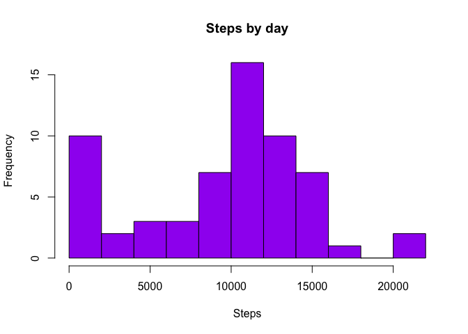

```r
activity_data_noNAs <- activity_data
activity_data_noNAs[is.na(activity_data_noNAs$steps), "steps"] <- 0

steps_by_date_noNAs <- aggregate(steps~date,activity_data_noNAs,sum)

hist(steps_by_date_noNAs$steps,breaks=10,main="Steps by day", xlab = "Steps", col = "purple")
```

- Replacing missing values with zeros causes the histogram to have more left most values.
- Calculate and report the **mean** and **median** total number of steps taken per day after imputing missing values. The mean and median are both less than the original with missing values.

```r
mean(steps_by_date_noNAs$steps)
```

```
## [1] 9354.23
```

```r
median(steps_by_date_noNAs$steps)
```

```
## [1] 10395
```

## Are there differences in activity patterns between weekdays and weekends?

- Create a new factor variable in the dataset with two levels – “weekday” and “weekend” indicating whether a given date is a weekday or weekend day.

```r
activity_data_noNAs$day_number <- as.POSIXlt(activity_data_noNAs$date)$wday
activity_data_noNAs$day_type <- as.factor(ifelse(activity_data_noNAs$day_number == 0 | activity_data_noNAs$day_number == 6, "weekend", "weekday"))

weekday_steps <- activity_data_noNAs[activity_data_noNAs$day_type == "weekday",]
weekend_steps <- activity_data_noNAs[activity_data_noNAs$day_type == "weekend",]
```

- Make a panel plot containing a time series plot (i.e. type = “l”) of the 5-minute interval (x-axis) and the average number of steps taken, averaged across all weekday days or weekend days (y-axis).

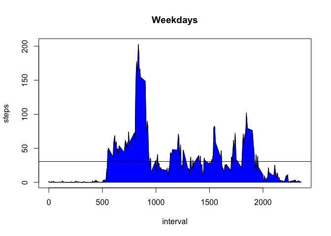

```r
steps_by_interval_weekdays <- aggregate(steps ~ interval, weekday_steps, mean)
steps_by_interval_weekends <- aggregate(steps ~ interval, weekend_steps, mean)

weekday_mean_steps = mean(steps_by_interval_weekdays$steps)
plot(steps_by_interval_weekdays, type = "l", main = "Weekdays")
xx <- c(steps_by_interval_weekdays$interval, rev(steps_by_interval_weekdays$interval))
yy <- c(rep(0, nrow(steps_by_interval_weekdays)), rev(steps_by_interval_weekdays$steps))
polygon(xx, yy, col='blue')
abline(h=weekday_mean_steps)
```

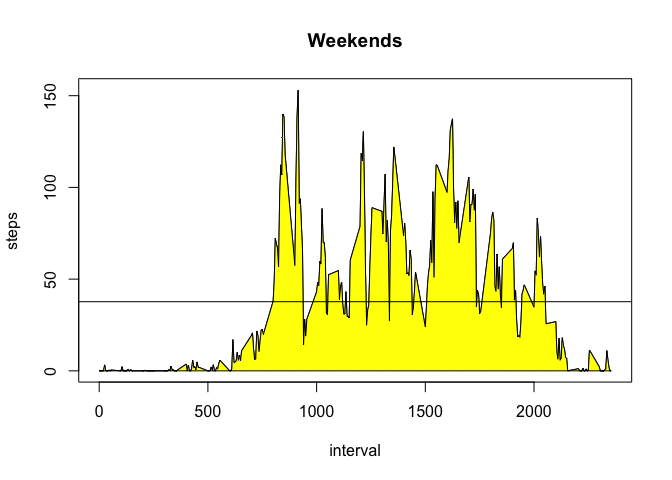

```r
weekend_mean_steps = mean(steps_by_interval_weekends$steps)
plot(steps_by_interval_weekends, type = "l", main = "Weekends")
xx <- c(steps_by_interval_weekends$interval, rev(steps_by_interval_weekends$interval))
yy <- c(rep(0, nrow(steps_by_interval_weekends)), rev(steps_by_interval_weekends$steps))
polygon(xx, yy, col='yellow')
abline(h=weekend_mean_steps)
```